# ISLR Chapter 4 Notes

Ryan Heslin

11/12/2020

```r
library(tidyverse)
library(rlang)
```

# Classification

## Overview

The general approach to classification is to find probabilities of each class and make a classification.

As with prediction, a classifier should perform well on test as well as training data.

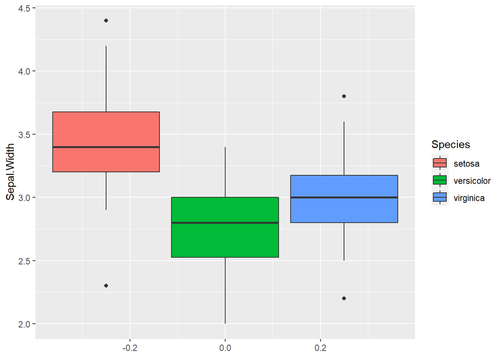

```r
library(tidyverse)
iris %>% ggplot(aes(x = Sepal.Width, fill = Species)) +
  geom_boxplot() +
  coord_flip()
```

## Why Not Linear Regression?

Linear regression is a poor choice for classification. Numerically coding the response variable creates an implicit order that may bnot logically exist:

$$Y =\Bigg\{
\begin{align}
\text{1 if stroke}\\
\text{2 if overdose}\\
\text{3 if seizure}
\end{align}
\right$$

Regression may be used where the outcome is binary and may be coded 0 or 1. However, OLS is inappropriate because it will predict probabilities outside $[0,1]$.

## Logistic Regression

These give the probability of the outcome:
$$P\text{(default = yes}\mid\text{balance}$$

The prediction is made at a given level of probability, which is chosen depending on whether Type I or Type II errors are more serious

## The Logistic Model

Again, OLS will predict impossible probabilities in most cases. Logistic models take the form:

$$p(X) = \frac{e^{\beta_0 +\beta_1X}}
{1 + e^{\beta_0 +\beta_1X}}$$

This is fitted using the maximum likelihood function. It always yields an S-shaped curve resembling the normal distribution’s CDF, where most probability change occurs in the middle of the interval. Adding 1 to the denominator ensures the probability is never greater than 1, constraining the predictions. The RHS is called the log odds.

This can be rewritten as:

$$\frac{p(X)}{1-p(X)} = e^{\beta_0 + \beta_1X}$$

For instance:

```r
p <- .95
p/ (1-p)
```

```
## [1] 19
```

Logging both sides of the odds equation gives:

$$\log(\frac{p(X)}{1- p(X)}) = \beta_0 + \beta_1X$$

So the regression equation gives the natural log of the odds - the *logit*. A one-unit increase in X increases the log odds by $\beta_1$ and multiplies the odds by $e^\beta_1$. This is a nonlinear relationship: the impact on the odds depends on the value of the predictor. The log odds are simply odds as multiples of e.

Logits are fitted using the maximum likelihood function, which is more general than the partial derivative optimizer used in OLS. The goal is to ensure each predicted probability is as close as possible to the observed class - 1 for yes and 0 for no (assuming that coding scheme).

$$l(\beta_0, \beta_1) = \prod_{i:y_i=1}p(x_i)\prod_{i':y_{i'} =0}(1-p(x_{i'}))$$

The values of $\beta_0$ and $\beta_1$ for which this product of summed products is highest are chose.

Once coefficients are chosen, predictions may be made for any X:

```r
b0 <- -10.65
b1 <- .0055
b2 <- .405
X = 1000
X2 <- 1
exp(b0 + b1*X)/ (1 + exp(b0 + b1*X))
```

```
## [1] 0.005765966
```

This gives a probability of under 1%.

Dummy variables can be added and are treated in the usual way, multiplying the coefficient by the numeric code

```r
exp(b0 + b1*X + b2*X2)/ (1 + exp(b0 + b1*X +b2*X2))
```

```
## [1] 0.00862011
```

Multiple logistic regression can introduce a subtlety. A predictor’s beta may change its sign as more predictors are added. This occurs because the beta indicates the average impact on Y holding *all other X constant*. When predictors are correlated, they are both associated with the outcome, but the relationship may change when their effects on each other are controlled for. For example, students have a higher overall default rate than nonstudents, but the coefficient of student in a multivariate model is negative because students have lower default rates than nonstudents *with the same balance*. This is an example of confounding. In other words, the students’ class mean is higher, but its classification curve gives a lower likelihood of default because student status correlates with predictors associated with sound credit.

Logistic regression is not recommended for multiple classes, since interpretation depends on coding schemes.

## Linear Discriminant Analysis

LDA extends logistic regression to multiple classes by modeling the predictors separately for each class of Y and use Bayes’ rule to derive estimates of class probability:
$$\Pr\text(Y = k|X = x)$$

In addition to doing well with multiple response classes, LDA is more stable with small n.

Bayes’ theorem is:
$$P(A|B) = \frac{P(B|A)P(A)}{P(B)}$$
or the ratio of events B conditioned on A weighted by A’s probability to all events B

So if a test is 90% sensitive and 80% specific, and the prevalence is 5%:

```r
pA <- .05
pBA <- .9
pB_notA <- .2
pB <- (pBA*pA) + (pB_notA * (1 - pA))

(pBA * pA) / pB
```

```
## [1] 0.1914894
```

$$\frac{.9 \times .05}{.9 \times .05 + .2 \times (1- .05)}$$
Note this simplifies to
$$\frac{1}{P(A^C) * (1-P(A))}$$
for a two-class situation; in other words, the inverse of the proportion of the sample space taken up by the event’s complement.

We can also speak of a Bayes factor. a multiplier that adjusts the prior odds of a condition given he results of a test. The formula is:

$$O(D|+)=O(D)\frac{P(+|D)}{P(+|-D)}$$
or the odds ratio of the prior to its complement (usually prevalence) multiplied by the odds ratio of true to to false positives (sensitivity to false positives) (or true to false negatives). The factor (the second term) expresses how much the test improves our certainty of the hypothesis from the posterior probability.

If a test has a 90% sensitivity rate and 1% false positive rate, for example, the factor is $\frac{90}{1}=90$, so a positive result increases the odds of having the disease by 90 times. Multiple factors can be applied if the patient takes multiple tests. Remember, multiplying odds ratios works differently than factions. So if prevalence is 1%:

$$1\colon99\times90=90\colon99\rightarrow\frac{90}{189}=0.48$$
for a 2-class situation where the odds of a positive test (pB) are the sum of sensitivity times prevalence (true positive) and specificity times the complement of prevalence (false positive). In this form, the equation essentially asks what fraction of positives are true. Even if sensitivity is perfect, imperfect specificity means many false positives. For two class situations, the denominator is:
$$P(B|A)P(A)\times P(B|A^C)(A^C)$$
where $A^C$ is $A$’s complement. From the Bayesian perspective, accuracy is meaningless without knowledge of the prior distribution ($P|A$).

### LDA Explained

We have $k$ classes. $\pi_k$ represents the prior probability (i.e., outside our model) of a random observation falling in each $k$. The density function of an observation for class k is:
$$f_k(x)= \Pr(X =x|Y=k)$$
The larger $f_k(x)$ for a given x, the higher the odds an observation of class $k$ has $x$. By Bayes’ theorem:

$$Pr(Y = k|X=x)=
\frac{\pi_kf_k(x)}
{\sum_{l=1}^{K}\pi_lf_l(x)}$$
Remember to substitute in $f_k(x)$! The odds of belonging to class $k$ for a given value of $x$ are the odds of class $k$ given that predictor’s value divided by the summed odds of the predictor taking that value for all classes. This is the same as dividing the likelihood of true positives by the likelihood of *any* positives. This is the posterior probability.

$\pi_k$ is easy to estimate from sample proportions of the class, but $f_k(x)$ is more challenging. Recall that we use the Bayes classifier, which chooses the class for which $p_k(X)$ is highest.

To start, we assumed $f_k(x)$ has normal density. For a single predictor, this is:

$$f_k(x) = \frac{1}{\sqrt{2\pi}\sigma_k}
\exp(-\frac{1}{2\sigma^2_k}(x-\mu_k)^2)$$

with $\mu_k$ and $\sigma^2_k$ are the mean and variance of class k. Thus the function differs for each class.

By substituting this formula for $f_k(x)$ into Bayes’ rule above, we get:

$$p_k(x) = \frac{\pi_k\frac{1}{\sqrt{2\pi}\sigma_k}
\exp(-\frac{1}{2\sigma^2_k}(x-\mu_k)^2)}
{\sum_{l=1}^K\pi_l\frac{1}{\sqrt{2\pi}\sigma_k}
\exp(-\frac{1}{2\sigma^2_k}(x-\mu_k)^2)}$$

By logging both sides, we can find the formula for the Bayes classifier, which assigns whichever class for which this value is highest:

$$\delta_k(x) = x\cdot\frac{\mu_k}{\sigma^2} -
\frac{\mu^2_k}{2\sigma^2} + \log(\pi_k)$$

Holding $\pi_k$ constant, x for a single class becomes:
$$\delta_k(x) =\frac{\mu_k}{2}$$
So if there are two classes with equal prior probabilities, the Bayesian decision boundary is simply the midpoint between the means.

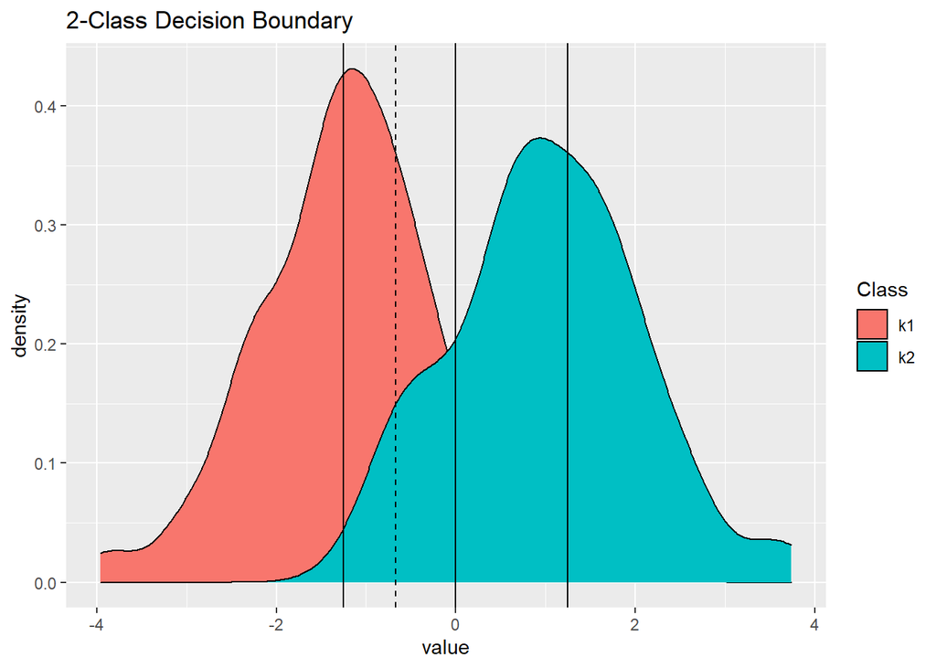

```r
tib <- tibble(k1 = rnorm(100, mean = -1.25), k2 = rnorm(100, mean = 1.25))

mu <- (mean(tib$k1) +mean(tib$k2) / 2)

  tib %>% pivot_longer(everything(), names_to = "Class") %>%
  ggplot(aes(value, fill =Class)) +
    geom_density() +
    geom_vline(xintercept = c(-1.25,0,1.25))+
  geom_vline(xintercept = mu, linetype = "dashed") +
    labs(title = "2-Class Decision Boundary")
```

In practice, we still need to estimate the means and variances for the class distributions, as well as the prior probability.
$$\mu_k = \frac{1}{n_k}\sum_{i:y_i=k}x_i$$

$$\sigma^2 = \frac{1}{n-K}\sum^K_{k=1}\sum_{i:y_i=k}(x_i-\mu_k)^2$$

so mean is simply the class mean, and variance is obtained by summing variances for each class and dividing by degrees of freedom (since we give one up for each class mean?). Prior probabilities are simply $\pi_k =\frac{n_k}{n}$

### LDA for p > 1

For this case, we assume that all predictors come from a multivariate normal distribution with distinct means for each predictor (the mean vector) but a common covariance matrix. $x$ here is vector of order $p$.

If predictors are uncorrelated, the multidimensional distribution resembles the familiar bell curve. If they are correlated, the shape is more elliptical. To indicate that X has a multivariate normal distribution, we write $X ~ N(\mu, \Sigma)$ Covariance has replaced variance as the parameter. The density is:

$$f(x) = \frac{1}{(2\pi)^{p/2}\lvert\Sigma\rvert^{\frac{1}{2}}}
\exp\big(\frac{-1}{2}(x-\mu)^T\Sigma^{-1}(x-\mu)\big)$$

The $\Sigma^{-1}$ term is precision - the inverse of the covariance matrix Remember that $\mu$ is a vector of $p$ predictor means. The optimizer equation is is simply a vectorized version of the one-predictor case that finds the most probable class for the observation vector. Both therms in the exrpession come to $1\times p$ row vectors.

## Errors and Caveats

If one class is rare, the null classifier can do very well by always excluding it. Recall that sensitivity is true positives and specificty true negatives. The Bayes classifier optimizes *overall* accuracy (class for which posterior probability is greatest), so it is inappropriate if one type of error is much more consequential than the other. In a 2-class case, the classifier threshold could be set to 20% to increase sensitivity.

The ROC curve displays performance across different thresholds. The area under the curve represents total performance; 1 would indicate perfection

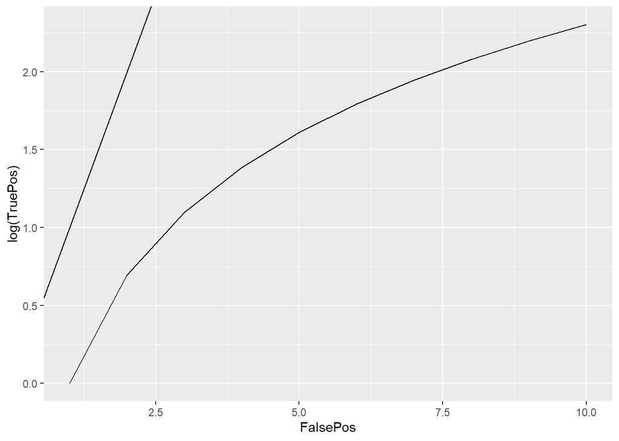

```r
data.frame(FalsePos = 1:10, TruePos = 1:10) %>%
  ggplot(aes(FalsePos, log(TruePos))) +
  geom_line() +
  geom_abline()
```

## Quadratic Discriminant Analysis

QDA assumes each class has it own covariance matrix with the other classes; that is, relationships among predictors vary by class. This adds $Kp(p+1)/2$ additional parameters to estimate (from the free parameters of each covariance matrix), greatly increasing flexibility at the cost of variance. It is warranted if there are very many training observations, or if it is known there is no common covariance matrix.

## Conclusion

LDA and log regression are fundamentally the same. 1-predictor LDA reduces to:
$$\log\Big(\frac{p_1(x)}{p_2(x)}\Big)=c_0 +c_{1x}$$

where the RHS derives from the model parameters. This is almost the same as the linear regression form, the only difference being the estimation method.

Overall, logistic regression and LDA are fairly close. KNN is far more flexible than any regression method but does not provide interpretable coefficients. QDA falls somewhere between LDA and QDA.

The correct decision depends on the shape of the theoretical Bayes decisions boundary - the less linear, the more flexible the appropriate model.